# Динамический анализ данных с R Markdown

Аналитик данных

2025-10-22

#

Анализ данных о фильмах Star Wars

*Динамический отчет с использованием R Markdown*

## Введение

Этот документ демонстрирует возможности **R Markdown** для создания динамических отчетов. Мы проанализируем данные о фильмах **Star Wars** из пакета `repurrrsive`.

Текущая дата: 2025-10-22

Общее количество фильмов в базе: 7

## Основная информация о фильмах

```r
films_df <- map_dfr(sw_films, ~{
  data.frame(
    Название = .x$title,
    Режиссер = .x$director,
    Продюсер = .x$producer,
    `Дата выхода` = .x$release_date,
    `Количество персонажей` = length(.x$characters),
    `Количество планет` = length(.x$planets),
    stringsAsFactors = FALSE
  )
})

kable(films_df, caption = "Информация о фильмах Star Wars")
```

Информация о фильмах Star Wars

| Название | Режиссер | Продюсер | Дата.выхода | Количество.персонажей | Количество.планет |
| --- | --- | --- | --- | --- | --- |
| A New Hope | George Lucas | Gary Kurtz, Rick McCallum | 1977-05-25 | 18 | 3 |
| Attack of the Clones | George Lucas | Rick McCallum | 2002-05-16 | 40 | 5 |
| The Phantom Menace | George Lucas | Rick McCallum | 1999-05-19 | 34 | 3 |
| Revenge of the Sith | George Lucas | Rick McCallum | 2005-05-19 | 34 | 13 |
| Return of the Jedi | Richard Marquand | Howard G. Kazanjian, George Lucas, Rick McCallum | 1983-05-25 | 20 | 5 |
| The Empire Strikes Back | Irvin Kershner | Gary Kutz, Rick McCallum | 1980-05-17 | 16 | 4 |
| The Force Awakens | J. J. Abrams | Kathleen Kennedy, J. J. Abrams, Bryan Burk | 2015-12-11 | 11 | 1 |

Самый ранний фильм вышел: 1977-05-25

Самый поздний фильм вышел: 2015-12-11

Среднее количество персонажей в фильме: 24.7

## Анализ персонажей

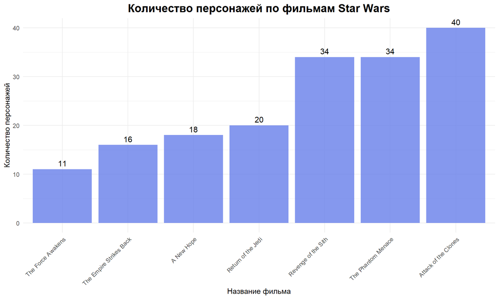

```r
character_counts <- films_df$Количество.персонажей
names(character_counts) <- films_df$Название

ggplot(films_df, aes(x = reorder(Название, Количество.персонажей), y = Количество.персонажей)) +
  geom_bar(stat = "identity", fill = "#667eea", alpha = 0.8) +
  geom_text(aes(label = Количество.персонажей), vjust = -0.5, size = 4) +
  labs(
    title = "Количество персонажей по фильмам Star Wars",
    x = "Название фильма",
    y = "Количество персонажей"
  ) +
  theme_minimal() +
  theme(
    axis.text.x = element_text(angle = 45, hjust = 1),
    plot.title = element_text(hjust = 0.5, size = 16, face = "bold")
  )
```

### Ключевые выводы по персонажам

Фильм с наибольшим количеством персонажей: **Attack of the Clones** (40 персонажей)

Фильм с наименьшим количеством персонажей: **The Force Awakens** (11 персонажей)

Разница между максимальным и минимальным количеством персонажей составляет: 29

## Детальный анализ по режиссерам

```r
directors_summary <- films_df %>%
  group_by(Режиссер) %>%
  summarise(
    `Количество фильмов` = n(),
    `Общее количество персонажей` = sum(Количество.персонажей),
    `Среднее количество персонажей` = round(mean(Количество.персонажей), 1),
    .groups = 'drop'
  )

kable(directors_summary, caption = "Статистика по режиссерам")
```

Статистика по режиссерам

| Режиссер | Количество фильмов | Общее количество персонажей | Среднее количество персонажей |
| --- | --- | --- | --- |
| George Lucas | 4 | 126 | 31.5 |
| Irvin Kershner | 1 | 16 | 16.0 |
| J. J. Abrams | 1 | 11 | 11.0 |
| Richard Marquand | 1 | 20 | 20.0 |

Всего уникальных режиссеров: 4

## Временной анализ

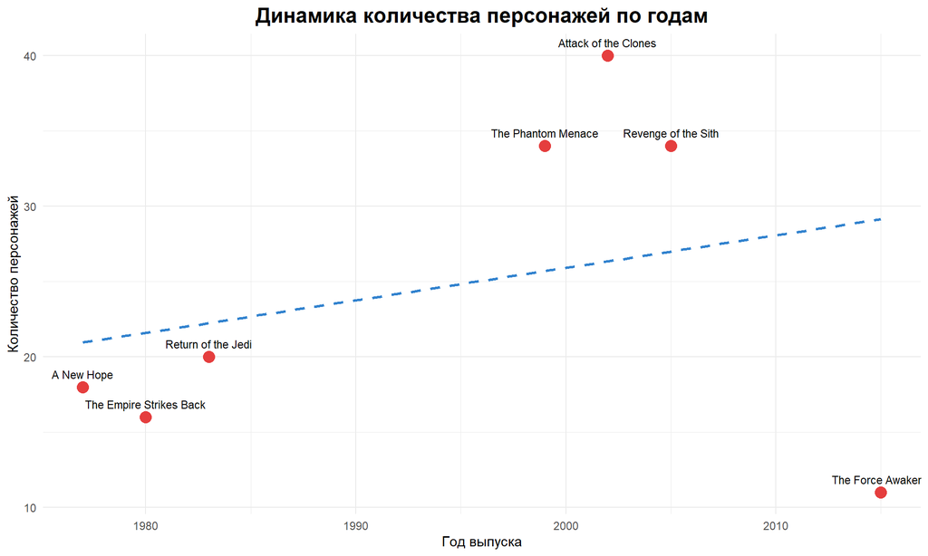

```r
films_df$Год <- as.numeric(substr(films_df$Дата.выхода, 1, 4))

ggplot(films_df, aes(x = Год, y = Количество.персонажей)) +
  geom_point(size = 4, color = "#e53e3e") +
  geom_smooth(method = "lm", se = FALSE, color = "#3182ce", linetype = "dashed") +
  geom_text(aes(label = Название), vjust = -1, size = 3) +
  labs(
    title = "Динамика количества персонажей по годам",
    x = "Год выпуска",
    y = "Количество персонажей"
  ) +
  theme_minimal() +
  theme(plot.title = element_text(hjust = 0.5, size = 16, face = "bold"))
```

### Статистические показатели

Средний год выпуска: 1994.4

Стандартное отклонение: 14.47

Коэффициент корреляции между годом и количеством персонажей: 0.281

## Интерактивные расчеты

```r
calculate_character_density <- function(film_title) {
  film <- films_df[films_df$Название == film_title, ]
  density <- film$Количество.персонажей / (2023 - film$Год)
  return(round(density, 3))
}
```

### Примеры расчетов:

Для фильма **“A New Hope”**: - Год выпуска: 1977 - Количество персонажей: 18 - “Плотность” персонажей: 0.391

Для фильма **“Revenge of the Sith”**: - Год выпуска: 2005 - Количество персонажей: 34 - “Плотность” персонажей: 1.889

## Заключение

Этот динамический отчет демонстрирует мощь R Markdown для анализа данных и создания воспроизводимых отчетов.

### Основные преимущества использованного подхода:

1. **Динамические вычисления** - все числа и графики обновляются автоматически
2. **Гибкое форматирование** - использование CSS для стилизации
3. **Интеграция кода и текста** - seamless сочетание анализа и выводов
4. **Воспроизводимость** - отчет можно легко обновить с новыми данными

Общее количество обработанных записей: 173 упоминаний персонажей между 7 фильмов.

*Конец отчета*